# **Understanding the Divergence**

## **Definition of Divergence**

The **divergence** of a vector field is a scalar function that measures the rate at which the vector field "spreads out" from a given point. Mathematically, for a vector field $\vec{F} = F_x\,\hat{i} + F_y\,\hat{j} + F_z\,\hat{k}$ in three-dimensional space, the divergence is defined as:

$$ \text{div}\,\vec{F} = \nabla \cdot \vec{F} = \frac{\partial F_x}{\partial x} + \frac{\partial F_y}{\partial y} + \frac{\partial F_z}{\partial z} $$

Here, $\nabla$ (del operator) is a vector differential operator, and the dot denotes the dot product.

In vector calculus, divergence is a vector operator that operates on a vector field, producing a scalar field giving the quantity of the vector field's source at each point. More technically, the divergence represents the volume density of the outward flux of a vector field from an infinitesimal volume around a given point.

As an example, consider air as it is heated or cooled. The velocity of the air at each point defines a vector field. While air is heated in a region, it expands in all directions, and thus the velocity field points outward from that region. The divergence of the velocity field in that region would thus have a positive value. While the air is cooled and thus contracting, the divergence of the velocity has a negative value.

## **Derivation of Divergence**

### **1. Conceptual Understanding**

To derive the divergence, consider how much of the vector field flows out of an infinitesimally small volume surrounding a point. The divergence at that point quantifies this net "outflow" per unit volume.

### **2. Mathematical Derivation**

**Step 1: Consider a Small Volume Element**

Imagine a small rectangular box (parallelepiped) centered at point $(x, y, z)$ with sides of length $dx$, $dy$, and $dz$.

**Step 2: Compute Flux Through Each Face**

- **Flux in the $x$-direction:**
  - **Right face at $x + \frac{dx}{2}$:** Outflow $F_x\left(x + \frac{dx}{2}, y, z\right) \, dy \, dz$
  - **Left face at $x - \frac{dx}{2}$:** Inflow $F_x\left(x - \frac{dx}{2}, y, z\right) \, dy \, dz$
  - **Net flux in $x$-direction:**

    $$ \Delta \Phi_x = \left[ F_x\left(x + \tfrac{dx}{2}, y, z\right) - F_x\left(x - \tfrac{dx}{2}, y, z\right) \right] dy \, dz $$
- **Similarly for $y$ and $z$-directions:**

  $$ \Delta \Phi_y = \left[ F_y\left(x, y + \tfrac{dy}{2}, z\right) - F_y\left(x, y - \tfrac{dy}{2}, z\right) \right] dx \, dz $$

  $$ \Delta \Phi_z = \left[ F_z\left(x, y, z + \tfrac{dz}{2}\right) - F_z\left(x, y, z - \tfrac{dz}{2}\right) \right] dx \, dy $$

**Step 3: Total Net Flux Out of the Volume**

$$ \Delta \Phi_{\text{total}} = \Delta \Phi_x + \Delta \Phi_y + \Delta \Phi_z $$

**Step 4: Use Taylor Series Expansion**

Assuming the field components are differentiable, we can approximate:

$$ F_x\left(x + \tfrac{dx}{2}, y, z\right) \approx F_x(x, y, z) + \tfrac{dx}{2} \frac{\partial F_x}{\partial x} $$

$$ F_x\left(x - \tfrac{dx}{2}, y, z\right) \approx F_x(x, y, z) - \tfrac{dx}{2} \frac{\partial F_x}{\partial x} $$

- **Net flux in $x$-direction becomes:**

  $$ \begin{align*} \Delta \Phi_x &= \left[ \left( F_x + \tfrac{dx}{2} \tfrac{\partial F_x}{\partial x} \right) - \left( F_x - \tfrac{dx}{2} \tfrac{\partial F_x}{\partial x} \right) \right] dy \, dz \\ &= \left( dx \frac{\partial F_x}{\partial x} \right) dy \, dz \end{align*} $$
- **Similarly for $y$ and $z$-directions.**

**Step 5: Calculate Divergence**

The divergence is the net flux per unit volume:

$$ \text{div}\,\vec{F} = \lim_{dx \to 0, dy \to 0, dz \to 0} \frac{\Delta \Phi_{\text{total}}}{dx \, dy \, dz} = \frac{\partial F_x}{\partial x} + \frac{\partial F_y}{\partial y} + \frac{\partial F_z}{\partial z} $$

## **Physical Meaning of Divergence**

### **1. Intuitive Interpretation**

- **Positive Divergence:** Indicates a "source" at that point where the field vectors are spreading out. For example, in fluid flow, it represents a point where fluid is being added.
- **Negative Divergence:** Indicates a "sink" where the field vectors are converging. In fluid flow, it's a point where fluid is being removed.
- **Zero Divergence:** The field is **solenoidal** (volume-preserving flow), meaning there's no net addition or removal at that point.

### **2. Examples**

- **Fluid Dynamics:** Incompressible fluids have a divergence of zero ($\nabla \cdot \vec{v} = 0$), meaning the fluid density remains constant, and there's no net flow into or out of any point.
- **Electromagnetism:** Gauss's law relates the divergence of the electric field to the charge density:

  $$ \nabla \cdot \vec{E} = \frac{\rho}{\varepsilon_0} $$

  This indicates that charges act as sources or sinks of the electric field.

### **3. Visualization**

Imagine a vector field representing airflow. At points where air is emanating (like from a fan), the divergence is positive. Where air is being sucked in (like into a vacuum cleaner), the divergence is negative. In regions where air flows uniformly without any accumulation or depletion, the divergence is zero.

## **Summary**

- **Divergence** quantifies the "spreading out" of a vector field from a point.
- It is calculated as the sum of the partial derivatives of the vector field's components with respect to their corresponding coordinates.
- Physically, it represents the net rate of "outflow" per unit volume at a point, indicating sources or sinks in the field.
- Divergence plays a crucial role in various fields like fluid mechanics, electromagnetism, and vector calculus theorems such as **Gauss's Divergence Theorem**.

Feel free to let me know if you need further clarification or additional examples related to divergence!

## **Additional Info**

https://en.wikipedia.org/wiki/Divergence

### Divergence of a Vector Field

The **divergence** of a vector field **F(x)** at a point **x₀** is defined as the limit of the ratio of the surface integral of **F** out of the closed surface of a volume **V** enclosing **x₀** to the volume of **V**, as **V** shrinks to zero:

$$ \text{div} \, \mathbf{F} |_{\mathbf{x_0}} = \lim_{V \to 0} \frac{1}{|V|} \oint_{S(V)} \mathbf{F} \cdot \hat{\mathbf{n}} \, dS $$

where |V| is the volume of **V**, S(V) is the boundary of **V**, and $\hat{\mathbf{n}}$ is the outward unit normal to that surface.

It can be shown that the above limit always converges to the same value for any sequence of volumes that contain **x₀** and approach zero volume. The result, **div F**, is a scalar function of **x**.

Since this definition is coordinate-free, it shows that the divergence is the same in any coordinate system. However, it is not often used practically to calculate divergence; when the vector field is given in a coordinate system, the coordinate definitions below are much simpler to use.

A vector field with zero divergence everywhere is called **solenoidal**—in which case any closed surface has no net flux across it.

[figure not shown]

The divergence at a point **x** is the limit of the ratio of the flux **Φ** through the surface **Si** (red arrows) to the volume **|Vi|** for any sequence of closed regions **V1, V2, V3, …** enclosing **x** that approaches zero volume:

$$ \text{div} \, \mathbf{F} = \lim_{|V_i| \to 0} \frac{\Phi(S_i)}{|V_i|} $$

[figure not shown]

*Image: "Divergence (captions).svg" by User:Bfoshizzle1 was created with Inkscape, licensed under [CC BY-SA 4.0](https://creativecommons.org/licenses/by-sa/4.0/), [Link](https://commons.wikimedia.org/w/index.php?curid=76803637).*

The divergence of different vector fields. The divergence of vectors from point **(x, y)** equals the sum of the partial derivative with respect to **x** of the x-component and the partial derivative with respect to **y** of the y-component at that point:

$$ \nabla \cdot \mathbf{V}(x, y) = \frac{\partial V_x(x, y)}{\partial x} + \frac{\partial V_y(x, y)}{\partial y} $$

## **Youtube Videos**

Div, Grad, and Curl: Vector Calculus Building Blocks for PDEs [Divergence, Gradient, and Curl] https://www.youtube.com/watch?v=lKXW7DRyyro

## **EXAMPLE: Positive Divergence**

## **1. Define the Vector Field**

Let's choose the vector field:

$$ \vec{F}(x, y) = \begin{bmatrix} x^3 \\ y^3 \end{bmatrix} $$

This vector field tends to increase rapidly with $x$ and $y$, and as we'll see, it has a positive divergence almost everywhere.

## **2. Compute the Divergence Analytically**

The divergence of a vector field $\vec{F}(x, y) = \begin{bmatrix} P(x, y) \\ Q(x, y) \end{bmatrix}$ in two dimensions is given by:

$$ \text{div}\,\vec{F} = \frac{\partial P}{\partial x} + \frac{\partial Q}{\partial y} $$

For our vector field:

- $P(x, y) = x^3$
- $Q(x, y) = y^3$

Compute the partial derivatives:

1. $\displaystyle \frac{\partial P}{\partial x} = \frac{\partial}{\partial x}(x^3) = 3x^2$
2. $\displaystyle \frac{\partial Q}{\partial y} = \frac{\partial}{\partial y}(y^3) = 3y^2$

Therefore, the divergence is:

$$ \text{div}\,\vec{F} = 3x^2 + 3y^2 = 3(x^2 + y^2) $$

Since $x^2$ and $y^2$ are always non-negative, the divergence $\text{div}\,\vec{F}$ is always **non-negative** and is **positive** everywhere except at the origin $(0, 0)$.

```python
# Import necessary libraries
import numpy as np
import plotly.graph_objects as go
```

```python
# Define the grid
x_range = y_range = np.linspace(-5, 5, 20)
X, Y = np.meshgrid(x_range, y_range)

# Define the vector field components
# F = [P(x, y), Q(x, y)] = [x^3, y^3]
P = X**3
Q = Y**3

# Compute the divergence: div F = dP/dx + dQ/dy
# Compute partial derivatives
dP_dx = 3 * X**2
dQ_dy = 3 * Y**2

# Compute divergence
div_F = dP_dx + dQ_dy  # Divergence is 3(x^2 + y^2)
```

```python
# Create quiver plot for the vector field
fig = go.Figure()

fig.add_trace(go.Cone(
    x=X.flatten(),
    y=Y.flatten(),
    z=np.zeros_like(X).flatten(),
    u=P.flatten(),
    v=Q.flatten(),
    w=np.zeros_like(X).flatten(),
    colorscale='Blues',
    sizemode='absolute',
    sizeref=5e2,  # Adjusted for better visualization
    showscale=False,
    anchor='tail',
    name='Vector Field'
))

# Create contour plot for divergence
fig.add_trace(go.Surface(
    x=X,
    y=Y,
    z=div_F,
    colorscale='Reds',
    opacity=0.7,
    showscale=True,
    colorbar=dict(title='Divergence'),
    name='Divergence'
))

# Update layout
fig.update_layout(
    title='Vector Field and its Divergence',
    scene=dict(
        xaxis_title='X',
        yaxis_title='Y',
        zaxis_title='Divergence',
        camera=dict(
            eye=dict(x=1.2, y=1.2, z=1.2)
        )
    ),
    width=800,
    height=800
)

# Show plot
fig.show()
```

### **Result**

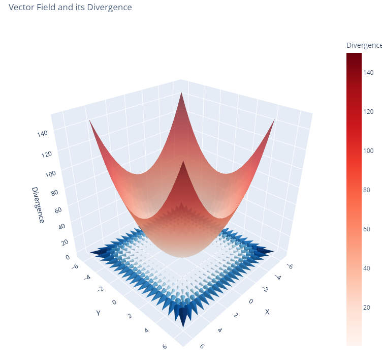

## **EXAMPLE: Negative Divergence**

## **1. Define the Vector Field**

We will define a vector field:

$$ \vec{F}(x, y) = \begin{bmatrix} -x \\ -y \end{bmatrix} $$

This vector field points towards the origin from any point $(x, y)$ in the plane.

## **2. Compute the Divergence Analytically**

The divergence of a vector field $\vec{F}(x, y) = \begin{bmatrix} P(x, y) \\ Q(x, y) \end{bmatrix}$ in two dimensions is given by:

$$ \text{div}\,\vec{F} = \frac{\partial P}{\partial x} + \frac{\partial Q}{\partial y} $$

For our vector field:

- $P(x, y) = -x$
- $Q(x, y) = -y$

Compute the partial derivatives:

1. **Partial derivative of $P$ with respect to $x$:**

   $$ \frac{\partial P}{\partial x} = \frac{\partial}{\partial x}(-x) = -1 $$
2. **Partial derivative of $Q$ with respect to $y$:**

   $$ \frac{\partial Q}{\partial y} = \frac{\partial}{\partial y}(-y) = -1 $$

Therefore, the divergence is:

$$ \text{div}\,\vec{F} = -1 + (-1) = -2 $$

The divergence is **constant and negative** everywhere in the plane.

```python
# Define the grid
x_range = y_range = np.linspace(-5, 5, 20)
X, Y = np.meshgrid(x_range, y_range)

# Define the vector field components
# F = [P(x, y), Q(x, y)] = [-x, -y]
P = -X
Q = -Y

# Compute the divergence: div F = dP/dx + dQ/dy
# Compute partial derivatives
dP_dx = -np.ones_like(X)
dQ_dy = -np.ones_like(Y)

# Compute divergence
div_F = dP_dx + dQ_dy  # Divergence is -2 everywhere
```

```python
# Create quiver plot for the vector field
fig = go.Figure()

fig.add_trace(go.Cone(
    x=X.flatten(),
    y=Y.flatten(),
    z=np.zeros_like(X).flatten(),
    u=P.flatten(),
    v=Q.flatten(),
    w=np.zeros_like(X).flatten(),
    colorscale='Blues',
    sizemode='absolute',
    sizeref=5,
    showscale=False,
    anchor='tail',
    name='Vector Field'
))

# Create contour plot for divergence
fig.add_trace(go.Surface(
    x=X,
    y=Y,
    z=div_F,
    colorscale='Reds',
    opacity=0.7,
    showscale=True,
    colorbar=dict(title='Divergence'),
    name='Divergence'
))

# Update layout
fig.update_layout(
    title='Vector Field with Negative Divergence',
    scene=dict(
        xaxis_title='X',
        yaxis_title='Y',
        zaxis_title='Divergence',
        camera=dict(
            eye=dict(x=1.2, y=1.2, z=1.2)
        )
    ),
    width=800,
    height=800
)

# Show plot
fig.show()
```

### **Result**

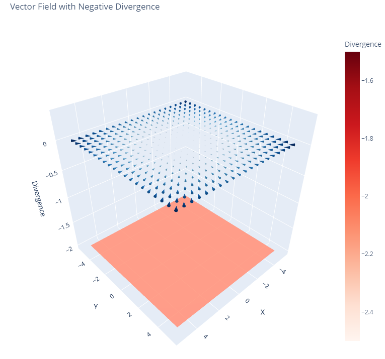

## **EXAMPLE: ZERO Divergence**

## **1. Define the Vector Field**

We will define a vector field:

$ \vec{F}(x, y) = \begin{bmatrix} -y \\ x \end{bmatrix} $

This vector field represents a rotational field, circulating around the origin.

## **2. Compute the Divergence Analytically**

The divergence of a vector field $\vec{F}(x, y) = \begin{bmatrix} P(x, y) \\ Q(x, y) \end{bmatrix}$ in two dimensions is given by:

$ \text{div}\,\vec{F} = \frac{\partial P}{\partial x} + \frac{\partial Q}{\partial y} $

For our vector field:

- $P(x, y) = -y$
- $Q(x, y) = x$

Compute the partial derivatives:

1. **Partial derivative of $P$ with respect to $x$:**

   $ \frac{\partial P}{\partial x} = \frac{\partial}{\partial x}(-y) = 0 $
2. **Partial derivative of $Q$ with respect to $y$:**

   $ \frac{\partial Q}{\partial y} = \frac{\partial}{\partial y}(x) = 0 $

Therefore, the divergence is:

$ \text{div}\,\vec{F} = 0 + 0 = 0 $

The divergence is **zero** everywhere in the plane, indicating that the field is **solenoidal** (no net outflow or inflow at any point).

```python
# Define the grid
x_range = y_range = np.linspace(-5, 5, 20)
X, Y = np.meshgrid(x_range, y_range)

# Define the vector field components
# F = [P(x, y), Q(x, y)] = [-y, x]
P = -Y
Q = X

# Compute the divergence: div F = dP/dx + dQ/dy
# Compute partial derivatives
dP_dx = np.zeros_like(X)  # d/dx of -Y is 0
dQ_dy = np.zeros_like(Y)  # d/dy of X is 0

# Compute divergence
div_F = dP_dx + dQ_dy  # Divergence is 0 everywhere
```

```python
# Create quiver plot for the vector field
fig = go.Figure()

fig.add_trace(go.Cone(
    x=X.flatten(),
    y=Y.flatten(),
    z=np.zeros_like(X).flatten(),
    u=P.flatten(),
    v=Q.flatten(),
    w=np.zeros_like(X).flatten(),
    colorscale='Blues',
    sizemode='absolute',
    sizeref=10,
    showscale=False,
    anchor='tail',
    name='Vector Field'
))

# Create contour plot for divergence
# Since divergence is zero, we'll plot it as a flat surface at z=0
fig.add_trace(go.Surface(
    x=X,
    y=Y,
    z=div_F,
    colorscale='Reds',
    opacity=0.5,
    showscale=True,
    colorbar=dict(title='Divergence'),
    name='Divergence'
))

# Update layout
fig.update_layout(
    title='Vector Field with Zero Divergence',
    scene=dict(
        xaxis_title='X',
        yaxis_title='Y',
        zaxis_title='Z',
        camera=dict(
            eye=dict(x=1.2, y=1.2, z=1.2)
        )
    ),
    width=800,
    height=800
)

# Show plot
fig.show()
```

### **Result**

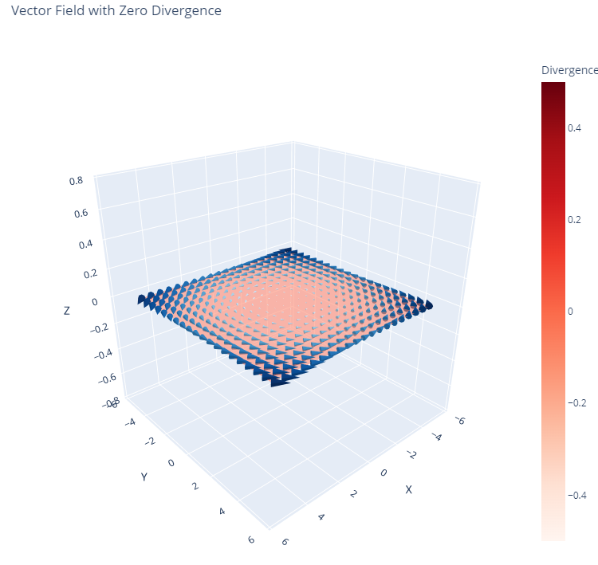